# Welcome on this dbt project on Aircraft Analytics

The goal of this project is that you bring a complete dbt configuration which will help gathering informations on Aircraft data

First of all, let's take the content of src/aircraft_db.sql and copy / paste it in a snowflake worksheet.

Be sure to select the transforming warehouse the raw database and the public schema.

run the script - it can take a few mins

check that the data is well loaded

```python
select * from raw.public.aircraft;
```

```python
select * from raw.public.airlines;
```

```python
select * from raw.public.airports;
```

```python
select * from raw.public.flight_summary_data;
```

# Configure your dbt project so that it reflects

Sources of your 4 tables Staging models, facts and dimensions (at least dim_aircraft, dim_airline and dim_airport)

```python
models/staging/sources.yml

- name: aircraft
    database: raw
    schema: public
    tables:
      - name: aircraft
      - name: airlines
      - name: airports
      - name: individual_flights
      - name: flight_summary_data
```

# Which aircraft has flown the most?

### modèle DBT de dim_aircraft

```
{{
  config(
    materialized='table',  )
}}

select
    a."Aircraft_Id",
    a."Aircraft_Type",
    COUNT(DISTINCT f."Flight_Id") AS "total_flights"
from {{ ref('stg_aircraft') }} a
join {{ ref('stg_individual_flight') }} f
on a."Aircraft_Id" = f."Aircraft_Id"
group by 1,2
```

### Sur snowflake :

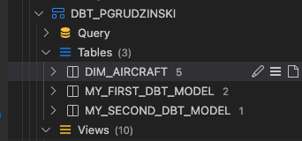

### Linéage sur DBT

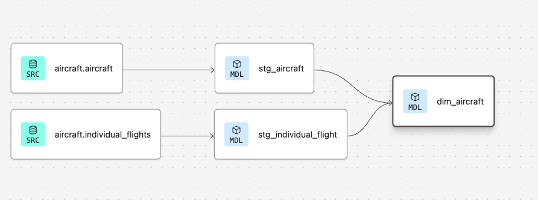

```python
select * from "DIM_AIRCRAFT"
```

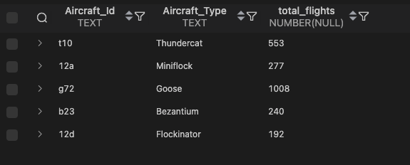

## Réultat sur deepnote

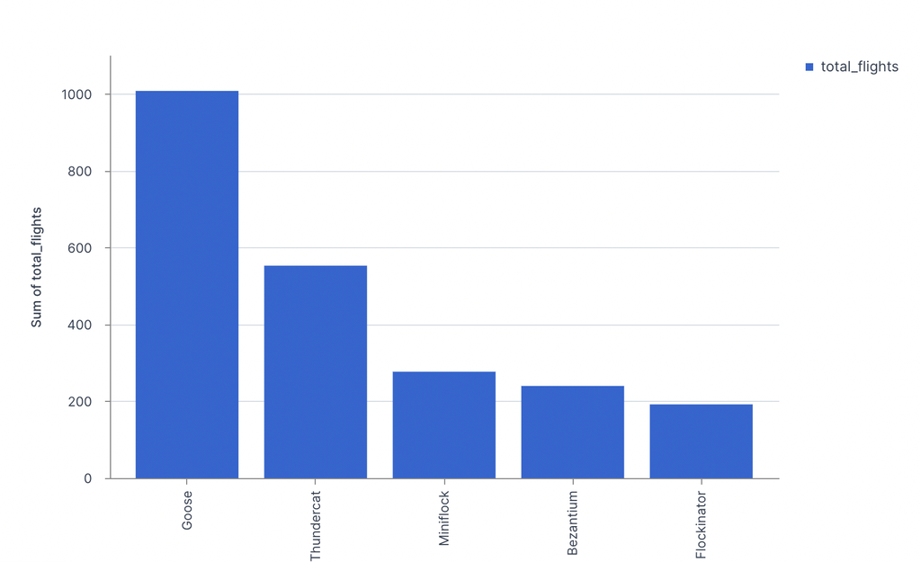

# Which airport has transported the most passengers through it?

### Calculate the number of passengers transported as the number of flights of each aircraft type, times its capacity, all together grouped by airport.

### It is worth mentioning that every individual flight will transport N passengers, but that will double count the number of people because it will be attributed to both airports (departure and destination) per flight, therefore, N would be attributed to airport A and airport B.

## tables intermédiaires dbt

```python
-- table intermédiaire "int_departure_airports" sur dbt
WITH flights AS (
    SELECT * FROM {{ ref('stg_individual_flight') }}
),
aircrafts AS (
    SELECT * FROM {{ ref('stg_aircraft') }}
),
airports AS (
    SELECT * FROM {{ ref('stg_airports') }}
)
SELECT
    f."Flight_Id",
    f."Departure_Airport_Code",
    a."Airport_Name",
    ac."Aircraft_Type",
    ac."Capacity"
FROM flights f
INNER JOIN airports a
    ON f."Departure_Airport_Code" = a."Airport_Code"
INNER JOIN aircrafts ac
    ON f."Aircraft_Id" = ac."Aircraft_Id"
-- table intermédiaire "int_destination_airports" sur dbt
WITH flights AS (
    SELECT * FROM {{ ref('stg_individual_flight') }}
),
aircrafts AS (
    SELECT * FROM {{ ref('stg_aircraft') }}
),
airports AS (
    SELECT * FROM {{ ref('stg_airports') }}
)
SELECT
    f."Flight_Id",
    f."Destination_Airport_Code",
    a."Airport_Name",
    ac."Aircraft_Type",
    ac."Capacity"
FROM flights f
INNER JOIN airports a
    ON f."Destination_Airport_Code" = a."Airport_Code"
INNER JOIN aircrafts ac
    ON f."Aircraft_Id" = ac."Aircraft_Id"
```

## tables dim.airports sur dbt

```python
{{
  config(
    materialized='table',  )
}}
WITH departure_passengers AS (
    SELECT
        "Flight_Id",
        "Departure_Airport_Code",
        NULL AS "Destination_Airport_Code",
        "Airport_Name",
        "Capacity"
    FROM {{ ref('int_departure_airports') }}
),
destination_passengers AS (
    SELECT
        "Flight_Id",
        "Destination_Airport_Code",
        NULL AS "Departure_Airport_Code",
        "Airport_Name",
        "Capacity"
    FROM {{ ref('int_destination_airports') }}
),
temp_total_passengers AS (
    SELECT
        "Flight_Id",
        COALESCE("Departure_Airport_Code", "Destination_Airport_Code") AS "Airport_Code",
        "Airport_Name",
        "Capacity"
    FROM departure_passengers
    UNION ALL
    SELECT
        "Flight_Id",
        COALESCE("Departure_Airport_Code", "Destination_Airport_Code") AS "Airport_Code",
        "Airport_Name",
        "Capacity"
    FROM destination_passengers
),
aggregated_passengers AS (
    SELECT
        "Airport_Name",
        SUM("Capacity") AS "total_passengers"
    FROM temp_total_passengers
    GROUP BY "Airport_Name"
)
SELECT
    "Airport_Name",
    "total_passengers"
FROM aggregated_passengers
ORDER BY "Airport_Name"
```

### Linéage sr DBT

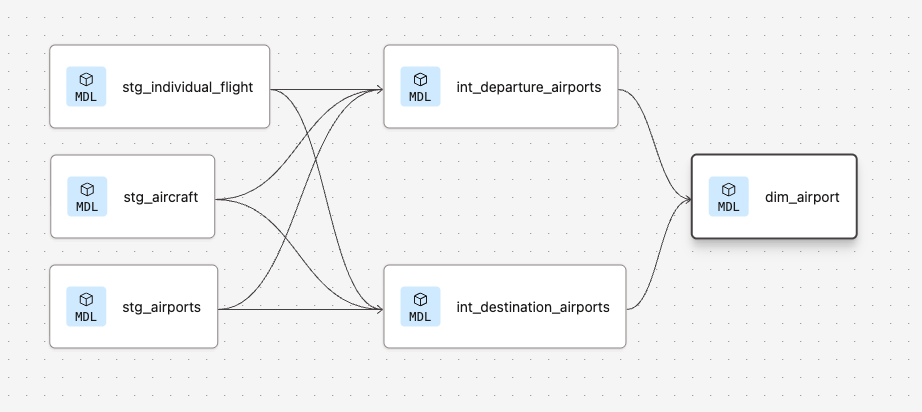

## Résultat sur snowflake

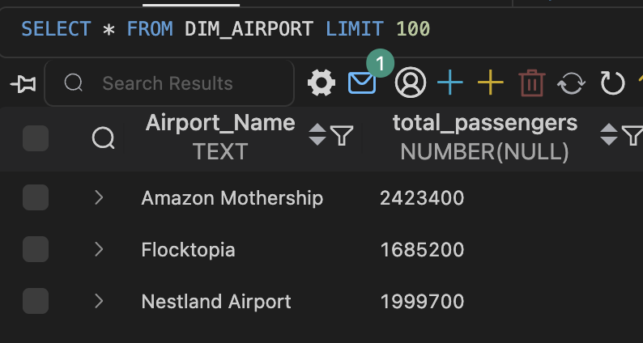

## Réultat sur deepnote

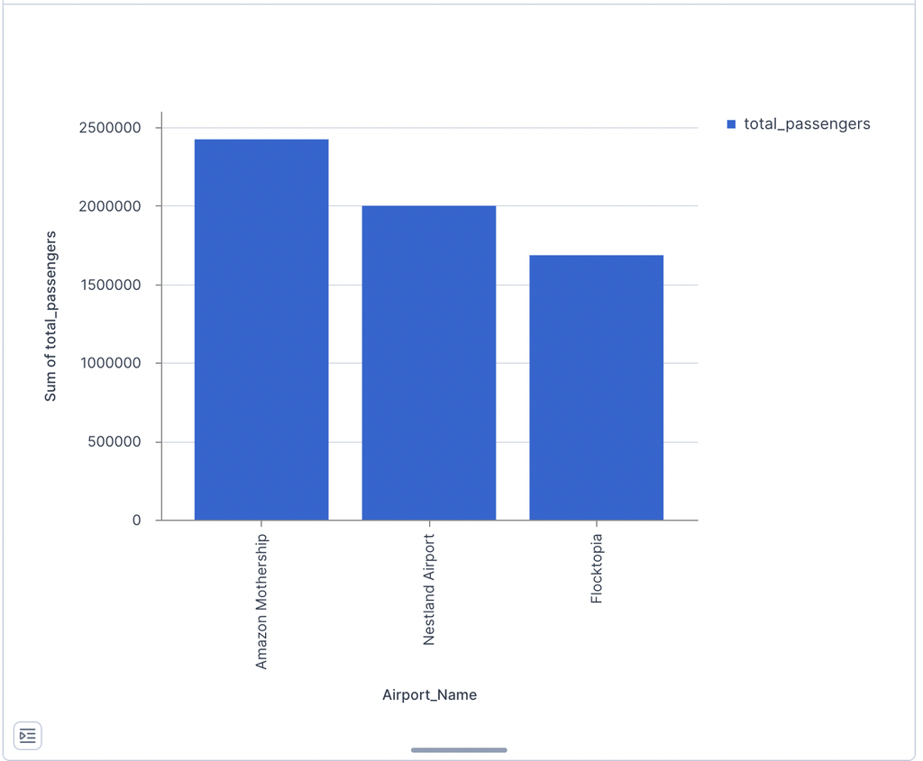

# What was the best year for Revenue Passenger-Miles for each airline?

## Tables intermediaires

```python
-- int_domestic_rpm.sql

WITH summary AS (
    SELECT * FROM {{ ref('stg_flitgh_summary_data') }}
),
airlines as
    (
        SELECT * FROM {{ ref('stg_airlines')}}
    )
SELECT
    s."Airline_Code",
    s."Date",
    a."Airline_Name",
    s."RPM_Domestic",
FROM summary s
INNER JOIN airlines a
    ON s."Airline_Code" = a."Airline_Code"

-- int_international_rpm.sql

WITH summary AS (
    SELECT * FROM {{ ref('stg_flitgh_summary_data') }}
),
airlines as
    (
        SELECT * FROM {{ ref('stg_airlines')}}
    )
SELECT
    s."Airline_Code",
    s."Date",
    a."Airline_Name",
    s."RPM_International",
FROM summary s
INNER JOIN airlines a
    ON s."Airline_Code" = a."Airline_Code"
```

## table de dimension

```python
-- dim_airlines
{{
  config(
    materialized='table')
}}
WITH domestic_rpm AS (
    SELECT
        *
    FROM {{ ref('int_domestic_rpm') }}
),
international_rpm AS (
    SELECT
        *
    FROM {{ ref('int_international_rpm') }}
),
total_rpm AS (
    SELECT
    "Airline_Code",
    "Airline_Name",
    EXTRACT(YEAR FROM CAST("Date" AS DATE)) as "Year",
    "RPM_Domestic",
    NULL AS "RPM_International"
FROM domestic_rpm
UNION ALL
SELECT
    "Airline_Code",
    "Airline_Name",
    EXTRACT(YEAR FROM CAST("Date" AS DATE)) as "Year",
    NULL AS "RPM_Domestic",
    "RPM_International",
FROM international_rpm
),
aggregated_domestic_rpm1 AS (
    SELECT
        "Airline_Name",
        "Year",
        SUM("RPM_Domestic") as "sum_domestic_rpm",
        SUM("RPM_International") as "sum_international_rpm"
    FROM total_rpm
    GROUP BY "Airline_Name", "Year"
),
aggregated_domestic_rpm2 AS (
    SELECT
        "Airline_Name",
        "Year",
        MAX("sum_domestic_rpm") as "max_domestic_rpm",
        MAX("sum_international_rpm") as "max_international_rpm"
    FROM aggregated_domestic_rpm1
    GROUP BY "Airline_Name", "Year"
),
ranked_aggregated_domestic_rpm AS (
Select
    "Airline_Name",
    "Year",
    "max_domestic_rpm"+"max_international_rpm" as "max_total_sum_rpm",
    RANK() OVER
    (PARTITION BY "Airline_Name" ORDER BY "max_total_sum_rpm" DESC) AS "Rank_max_total_rpm",
FROM aggregated_domestic_rpm2
WHERE "max_international_rpm" IS NOT NULL
)
SELECT
    *
FROM ranked_aggregated_domestic_rpm
WHERE "Rank_max_total_rpm" = 1
```

### Linéage sur DBT

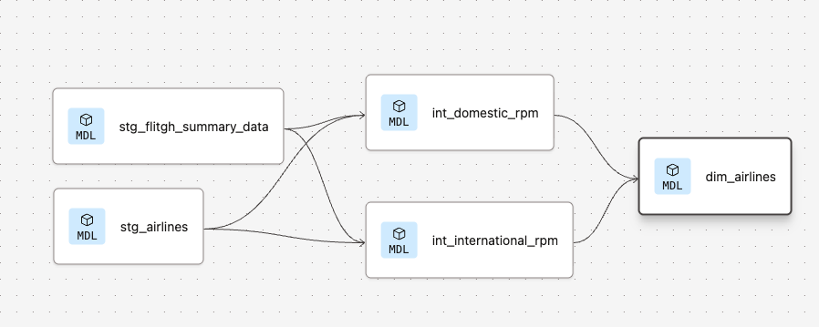

## Résultat sur snowflake

```python
SELECT * FROM DIM_AIRLINES
```

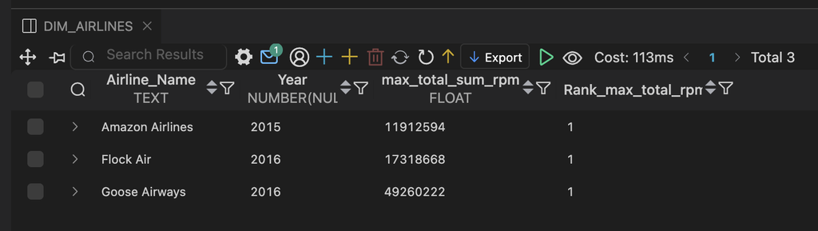

# What was the best year for growth for each airline?

### We have ASM and RPM, as well the number of flights Domestic and for some flights International, per Airline and Airport. To list some of the possible ways of evaluate growth, we have: Decrease the difference between ASM - RPM, therefore captivating more passengers out of the ones that they had the capacity for. Increase on ASM, therefore increasing the fleet or the size of the planes, or the number of flights. Increase in number of flights alone.

### For simplicity and because it seems to be the one providing the best answer, we will use ASM as our growth indicator, and the more ASM an airline has over time, the more we will say they grew.

### To calculate the growth we will take the AVG(ASM_Domestic) per Airline per Year.

## tables intermédiaires

```python
-- int_domestic_ASM

WITH summary AS (
    SELECT * FROM {{ ref('stg_flitgh_summary_data') }}
),
airlines as
    (
        SELECT * FROM {{ ref('stg_airlines')}}
    )
SELECT
    s."Airline_Code",
    s."Date",
    a."Airline_Name",
    s."ASM_Domestic",
FROM summary s
INNER JOIN airlines a
    ON s."Airline_Code" = a."Airline_Code"
```

## table de dimension

```python
{{
  config(
    materialized='table')
}}
WITH domestic_asm AS (
    SELECT
    "Airline_Code",
    "Airline_Name",
    EXTRACT(YEAR FROM CAST("Date" AS DATE)) as "Year",
    "ASM_Domestic"
    FROM {{ ref('int_domestic_ASM') }}
),
aggregated_domestic_asm AS (
    SELECT
        "Airline_Name",
        "Year",
        AVG("ASM_Domestic") as "avg_domestic_asm"
    FROM domestic_asm
    GROUP BY "Airline_Name", "Year"
),
lagged_domestic_asm AS (
SELECT
    "Airline_Name",
    "Year",
    "avg_domestic_asm",
    LAG("avg_domestic_asm") OVER(ORDER BY "Airline_Name", "Year") AS "one_year_before",
    "avg_domestic_asm" - LAG("avg_domestic_asm") OVER(ORDER BY "Airline_Name", "Year") AS "yearly_change",
    (("avg_domestic_asm" - LAG("avg_domestic_asm") OVER(ORDER BY "Airline_Name", "Year")) * 100 /
    NULLIF(LAG("avg_domestic_asm") OVER(PARTITION BY "Airline_Name" ORDER BY "Year"), 0)) AS "yearly_perc_change"
FROM aggregated_domestic_asm
),
ranked_lagged_asm AS (
SELECT
    "Airline_Name",
    "Year",
    "avg_domestic_asm",
    "one_year_before",
    "yearly_change",
    "yearly_perc_change",
    RANK() OVER
    (PARTITION BY "Airline_Name" ORDER BY "yearly_perc_change" DESC) AS "Rank_yearly_perc_change"
FROM lagged_domestic_asm
WHERE "yearly_perc_change" IS NOT NULL

)
SELECT
*
FROM ranked_lagged_asm
WHERE "Rank_yearly_perc_change" = 1
```

### Linéage sur DBT

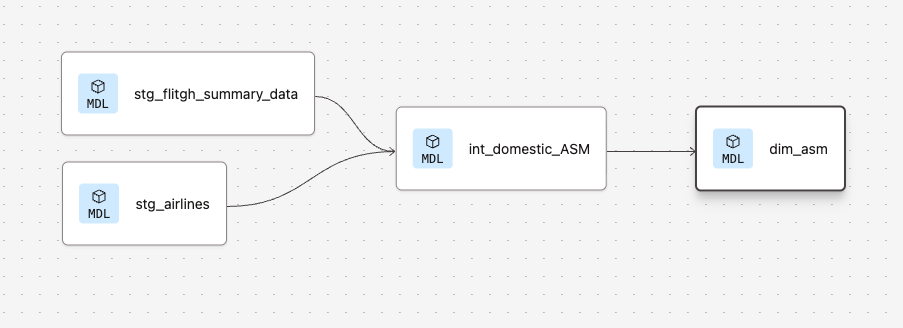

## Résultat sur snowflake

```python
select * from DIM_ASM
```

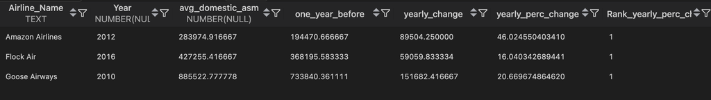